# CMTH 642 Data Analytics: Advanced Methods

# Assignment 3 (10%)

### DHC 500163559

#### 1. Import to R the following fiel: http://archive.ics.uci.edu/ml/machine-learning-databases/wine-quality/winequality-white.csv (The dataset is related to white Portuguese “Vinho Verde” wine. For more info: https://archive.ics.uci.edu/ml/datasets/Wine+Quality) (3 points)

```r
df <- read.csv("http://archive.ics.uci.edu/ml/machine-learning-databases/wine-quality/winequality-white.csv", sep = ";")
```

#### 2. Check the datatypes of the attributes. (3 points)

```r
sapply(df, class)
```

```
##        fixed.acidity     volatile.acidity          citric.acid
##            "numeric"            "numeric"            "numeric"
##       residual.sugar            chlorides  free.sulfur.dioxide
##            "numeric"            "numeric"            "numeric"
## total.sulfur.dioxide              density                   pH
##            "numeric"            "numeric"            "numeric"
##            sulphates              alcohol              quality
##            "numeric"            "numeric"            "integer"
```

#### 3. Are there any missing values in the dataset? (4 points)

```r
sum(complete.cases(df)) == nrow(df)
```

```
## [1] TRUE
```

```r
library(rapportools)
colSums(!is.empty(df))
```

```
##        fixed.acidity     volatile.acidity          citric.acid
##                 4898                 4898                 4879
##       residual.sugar            chlorides  free.sulfur.dioxide
##                 4898                 4898                 4898
## total.sulfur.dioxide              density                   pH
##                 4898                 4898                 4898
##            sulphates              alcohol              quality
##                 4898                 4898                 4898
```

```r
# there appears some missed counts at citric.acid so we further investigate the column.
df[is.empty(df$citric.acid),]
```

```
##      fixed.acidity volatile.acidity citric.acid residual.sugar chlorides
## 116            5.5            0.485           0            1.5     0.065
## 301            6.1            0.410           0            1.6     0.063
## 303            6.1            0.410           0            1.6     0.063
## 781            6.0            0.395           0            1.4     0.042
## 863            4.8            0.340           0            6.5     0.028
## 865            4.8            0.330           0            6.5     0.028
## 891            5.0            0.310           0            6.4     0.046
## 1153           6.1            0.600           0            1.3     0.042
## 1818           7.2            0.500           0            0.8     0.034
## 2322           4.6            0.445           0            1.4     0.053
## 2630           5.8            0.600           0            1.3     0.044
## 3455           5.8            0.540           0            1.4     0.033
## 3572           5.9            0.655           0            5.6     0.033
## 3636           5.8            0.580           0            1.5     0.020
```

[output cut: 45 more lines]

```r
# Turns out they are just 0s which is normal for citric acid.
# Therefore conclude there are no invalid empty values.
```

#### 4. What is the correlation between the attributes other than Quality? (10 points)

```r
df.noquality <- df[,-12]
cor(df.noquality)
```

```
##                      fixed.acidity volatile.acidity citric.acid residual.sugar
## fixed.acidity           1.00000000      -0.02269729  0.28918070     0.08902070
## volatile.acidity       -0.02269729       1.00000000 -0.14947181     0.06428606
## citric.acid             0.28918070      -0.14947181  1.00000000     0.09421162
## residual.sugar          0.08902070       0.06428606  0.09421162     1.00000000
## chlorides               0.02308564       0.07051157  0.11436445     0.08868454
## free.sulfur.dioxide    -0.04939586      -0.09701194  0.09407722     0.29909835
## total.sulfur.dioxide    0.09106976       0.08926050  0.12113080     0.40143931
## density                 0.26533101       0.02711385  0.14950257     0.83896645
## pH                     -0.42585829      -0.03191537 -0.16374821    -0.19413345
## sulphates              -0.01714299      -0.03572815  0.06233094    -0.02666437
## alcohol                -0.12088112       0.06771794 -0.07572873    -0.45063122
##                        chlorides free.sulfur.dioxide total.sulfur.dioxide
## fixed.acidity         0.02308564       -0.0493958591          0.091069756
## volatile.acidity      0.07051157       -0.0970119393          0.089260504
## citric.acid           0.11436445        0.0940772210          0.121130798
## residual.sugar        0.08868454        0.2990983537          0.401439311
## chlorides             1.00000000        0.1013923521          0.198910300
## free.sulfur.dioxide   0.10139235        1.0000000000          0.615500965
## total.sulfur.dioxide  0.19891030        0.6155009650          1.000000000
## density               0.25721132        0.2942104109          0.529881324
## pH                   -0.09043946       -0.0006177961          0.002320972
## sulphates             0.01676288        0.0592172458          0.134562367
## alcohol              -0.36018871       -0.2501039415         -0.448892102
##                          density            pH   sulphates     alcohol
## fixed.acidity         0.26533101 -0.4258582910 -0.01714299 -0.12088112
## volatile.acidity      0.02711385 -0.0319153683 -0.03572815  0.06771794
## citric.acid           0.14950257 -0.1637482114  0.06233094 -0.07572873
## residual.sugar        0.83896645 -0.1941334540 -0.02666437 -0.45063122
## chlorides             0.25721132 -0.0904394560  0.01676288 -0.36018871
## free.sulfur.dioxide   0.29421041 -0.0006177961  0.05921725 -0.25010394
## total.sulfur.dioxide  0.52988132  0.0023209718  0.13456237 -0.44889210
## density               1.00000000 -0.0935914935  0.07449315 -0.78013762
## pH                   -0.09359149  1.0000000000  0.15595150  0.12143210
## sulphates             0.07449315  0.1559514973  1.00000000 -0.01743277
## alcohol              -0.78013762  0.1214320987 -0.01743277  1.00000000
```

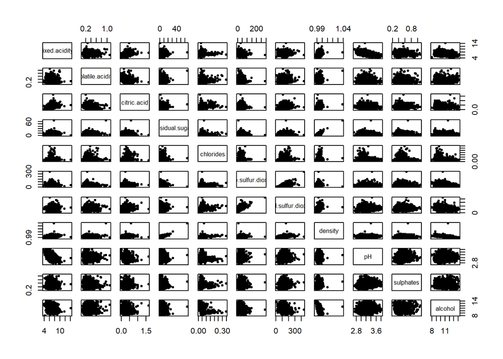

```r
plot(df.noquality, pch=20)
```

#### 5. Graph the frequency distribution of wine quality by using Quality. (10 points)

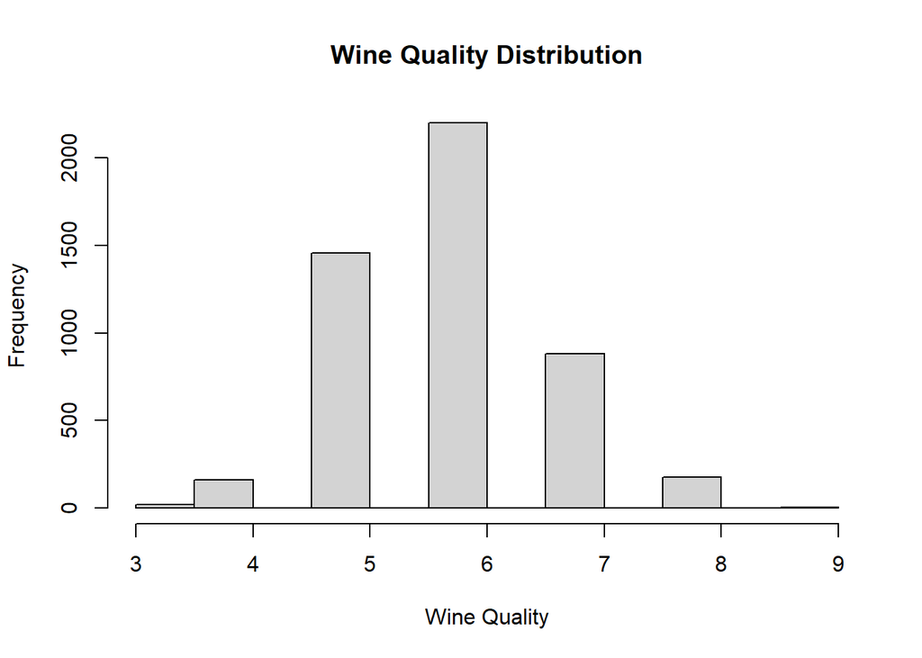

```r
hist(df$quality, main="Wine Quality Distribution", xlab = "Wine Quality")
```

#### 6. Reduce the levels of rating for quality to three levels as high, medium and low. Assign the levels of 3 and 4 to level 0; 5 and 6 to level 1; and 7,8 and 9 to level 2. (10 points)

```r
df.slicing <- cut(df$quality, breaks=c(2, 4, 6, 9))
levels(df.slicing) <- c(0:2)
df$qualitylevels <- df.slicing
```

#### 7. Normalize the data set by using the following function: (12 points)

```r
normalize <- function(x){
  return ((x - min(x)) / (max(x) - min(x)))
}
```

```r
df.normalized <- data.frame(lapply(df[1:11], normalize))
colnames(df.normalized) <- paste(colnames(df.normalized), "norm", sep = ".")
df.normalized$qualitylevels <- df$qualitylevels
```

#### 8. Divide the dataset to training and test sets. (12 points)

```r
set.seed(888)
train_index <- sample(1:nrow(df.normalized), 0.8*nrow(df.normalized))
df.train <- df.normalized[train_index,]
df.test <- df.normalized[-train_index,]
```

#### 9. Use the KNN algorithm to predict the quality of wine using its attributes. (12 points)

```r
library(class)
library(gmodels)
df.knn <- knn(train = df.train[,-12], test = df.test[,-12], cl=df.train$qualitylevels, k=13)
```

#### 10. Display the confusion matrix to evaluate the model performance. (12 points)

```r
#install.packages('caret', dependencies = TRUE)
library(caret)
cm <- confusionMatrix(df.knn, df.test$qualitylevels)
cm
```

```
## Confusion Matrix and Statistics
##
##           Reference
## Prediction   0   1   2
##          0   1   2   0
##          1  29 661 120
##          2   5  58 104
##
## Overall Statistics
##
##                Accuracy : 0.7816
##                  95% CI : (0.7544, 0.8071)
##     No Information Rate : 0.7357
##     P-Value [Acc > NIR] : 0.0005138
##
##                   Kappa : 0.3811
##
##  Mcnemar's Test P-Value : 7.564e-11
##
## Statistics by Class:
##
##                      Class: 0 Class: 1 Class: 2
## Sensitivity          0.028571   0.9168   0.4643
## Specificity          0.997884   0.4247   0.9167
## Pos Pred Value       0.333333   0.8160   0.6228
## Neg Pred Value       0.965200   0.6471   0.8524
## Prevalence           0.035714   0.7357   0.2286
## Detection Rate       0.001020   0.6745   0.1061
## Detection Prevalence 0.003061   0.8265   0.1704
## Balanced Accuracy    0.513228   0.6707   0.6905
```

#### 11. Evaluate the model performance by computing Accuracy, Sensitivity and Specificity. (12 points)

```r
writeLines(paste0("Accuracy: ", cm$overall['Accuracy']))
```

```
## Accuracy: 0.781632653061225
```

```r
writeLines("\nSensitivity: TP / (TP + FN)")
```

```
##
## Sensitivity: TP / (TP + FN)
```

```r
writeLines(paste0("class ", c(0:2),": ", cm$byClass[1:3]))
```

```
## class 0: 0.0285714285714286
## class 1: 0.916782246879334
## class 2: 0.464285714285714
```

```r
writeLines("\nSpecificity: TN / (TN + FP)")
```

```
##
## Specificity: TN / (TN + FP)
```

```r
writeLines(paste0("class ", c(0:2),": ", cm$byClass[4:6]))
```

```
## class 0: 0.997883597883598
## class 1: 0.424710424710425
## class 2: 0.916666666666667
```

This is the end of Assignment 3

Ceni Babaoglu, PhD